# Assignment 3

Ariel Bi

9/20/2020

```r
library(ggplot2)
library(tidyverse)
library(tidycensus)
```

I have chosen to analyze the relationship between the ability to speak English, citizenship status, wage or salary in the past 12 months, age, and usual hours worked per week. My sample population is the adult population of Massachusetts.

1. Ability to speak english ENG (categorical)
2. Citizenship status CIT (Categorical)
3. Wages or salary income past 12 month WAGP (Continuous)
4. Age AGEP (Continuous)
5. Usual hours worked per week past 12 months WKHP (Continuous)

```r
dataset=read.csv("ArielBi_people.csv")
filtered_dataset = filter(dataset,AGEP >= 18) # I have only selected adults over the age of 18.
```

```r
#perform chi-square test between 2 categorical variables
chisq_result = chisq.test(filtered_dataset$ENG_label, filtered_dataset$CIT_label, correct=TRUE)
chisq_result
```

```
##
##  Pearson's Chi-squared test
##
## data:  filtered_dataset$ENG_label and filtered_dataset$CIT_label
## X-squared = 31344, df = 16, p-value < 2.2e-16
```

Since p-value<2.2e-16,there is sufficient evidence that there is a relationship between the 2 variables.

```r
factor_CIT_label = as.factor(filtered_dataset$CIT_label)
levels(factor_CIT_label)
```

```
## [1] "Born abroad of American parent(s)"
## [2] "Born in Puerto Rico, Guam, the U.S. Virgin Islands, or the Northern Marianas"
## [3] "Born in the U.S."
## [4] "Not a citizen of the U.S."
## [5] "U.S. citizen by naturalization"
```

```r
table(filtered_dataset$ENG_label,as.numeric(factor_CIT_label))
```

```
##
##                                                       1     2     3     4     5
##   N/A (less than 5 years old/speaks only English)   428    91 43182   737  1429
##   Not at all                                          3    80    15   360   189
##   Not well                                           16   167    83   610   649
##   Very well                                         142   379  2658  1498  2345
##   Well                                               26   182   229   816  1199
```

The vast majority of people who are born in the U.S (category 3) only speaks English.

```r
# perform correlation test between continuous variables annual wage and age.
correlation = cor.test(filtered_dataset$WAGP, filtered_dataset$AGEP, method = "pearson")
correlation
```

```
##
##  Pearson's product-moment correlation
##
## data:  filtered_dataset$WAGP and filtered_dataset$AGEP
## t = -18.103, df = 57511, p-value < 2.2e-16
## alternative hypothesis: true correlation is not equal to 0
## 95 percent confidence interval:
##  -0.08339660 -0.06714377
## sample estimates:
##         cor
## -0.07527518
```

Since p-value<2.2e-16,there is sufficient evidence that there is a relationship between the 2 variables.

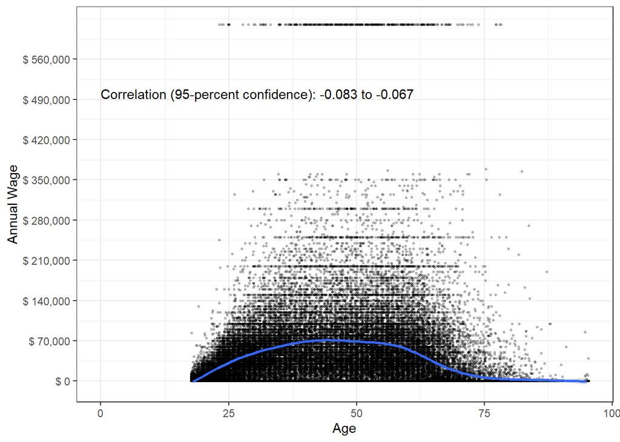

```r
ggplot(filtered_dataset, aes(x = AGEP, y = WAGP)) +
  geom_point(size = 0.5, alpha = 0.25, position = "jitter") +
  geom_smooth() +
  theme_bw() +
  scale_x_continuous(name = "Age") +
  scale_y_continuous(name = "Annual Wage",
                     breaks = seq(0, 620000, by = 70000),
                     labels = paste("$",
                                    prettyNum(seq(0, 620000, by = 70000),
                                              big.mark = ","))) +
  annotate(geom = "text", x = 0, y = 500000,
           label = paste("Correlation (95-percent confidence):",
                         prettyNum(correlation$conf.int[1], digits = 2),
                         "to",
                         prettyNum(correlation$conf.int[2], digits = 2)),
           hjust = 0)
```

```r
# perform correlation test between continuous variables annual wage and work hours per week.
correlation = cor.test(filtered_dataset$WAGP, filtered_dataset$WKHP, method = "pearson")
correlation
```

```
##
##  Pearson's product-moment correlation
##
## data:  filtered_dataset$WAGP and filtered_dataset$WKHP
## t = 147.36, df = 57511, p-value < 2.2e-16
## alternative hypothesis: true correlation is not equal to 0
## 95 percent confidence interval:
##  0.5175864 0.5294518
## sample estimates:
##       cor
## 0.5235444
```

Since p-value<2.2e-16,there is sufficient evidence that there is a relationship between the 2 variables.

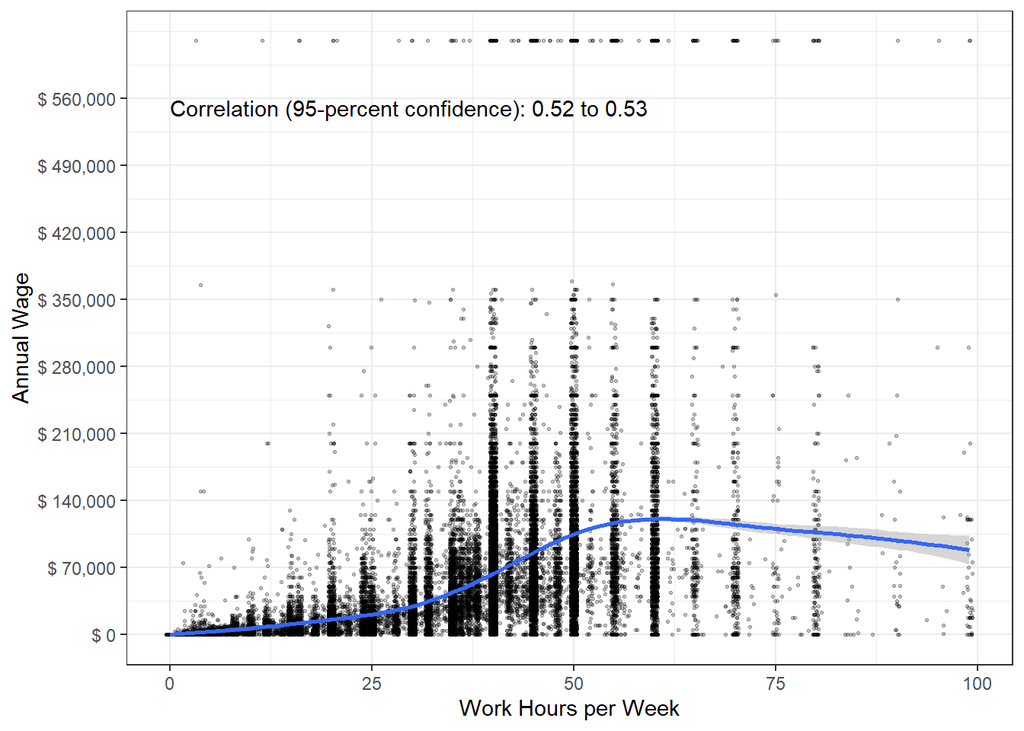

```r
ggplot(filtered_dataset, aes(x = WKHP, y = WAGP)) +
  geom_point(size = 0.5, alpha = 0.25, position = "jitter") +
  geom_smooth() +
  theme_bw() +
  scale_x_continuous(name = "Work Hours per Week") +
  scale_y_continuous(name = "Annual Wage",
                     breaks = seq(0, 620000, by = 70000),
                     labels = paste("$",
                                    prettyNum(seq(0, 620000, by = 70000),
                                              big.mark = ","))) +
  annotate(geom = "text", x = 0, y = 550000,
           label = paste("Correlation (95-percent confidence):",
                         prettyNum(correlation$conf.int[1], digits = 2),
                         "to",
                         prettyNum(correlation$conf.int[2], digits = 2)),
           hjust = 0)
```

Most people in the selected population group work for 40-60 hours per week. There is a leveling off of wages for individuals who work more than 70 hours per week.

```r
# perform correlation test between continuous variables age and work hours per week.
correlation = cor.test(filtered_dataset$AGEP, filtered_dataset$WKHP, method = "pearson")
correlation
```

```
##
##  Pearson's product-moment correlation
##
## data:  filtered_dataset$AGEP and filtered_dataset$WKHP
## t = -90.017, df = 57511, p-value < 2.2e-16
## alternative hypothesis: true correlation is not equal to 0
## 95 percent confidence interval:
##  -0.3585613 -0.3442344
## sample estimates:
##        cor
## -0.3514184
```

Since p-value<2.2e-16,there is sufficient evidence that there is a relationship between the 2 variables.

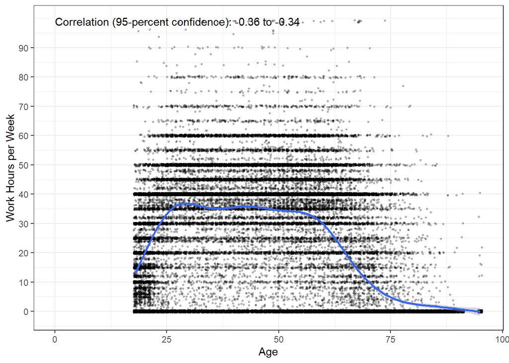

```r
ggplot(filtered_dataset, aes(x = AGEP, y = WKHP)) +
  geom_point(size = 0.5, alpha = 0.25, position = "jitter") +
  geom_smooth() +
  theme_bw() +
  scale_x_continuous(name = "Age") +
  scale_y_continuous(name = "Work Hours per Week",
                     breaks = seq(0, 99, by = 10),
                     labels = paste(prettyNum(seq(0, 99, by = 10),
                                              big.mark = ","))) +
  annotate(geom = "text", x = 0, y = 99,
           label = paste("Correlation (95-percent confidence):",
                         prettyNum(correlation$conf.int[1], digits = 2),
                         "to",
                         prettyNum(correlation$conf.int[2], digits = 2)),
           hjust = 0)
```

The average work hours per week for people between the age of 25 and 60 is 35 hours. People start to retire from their jobs around the age of 60.

```r
# perform ANOVA test between annual wage and ability to speak english.
anova_test = aov(WAGP ~ ENG_label,data=filtered_dataset)
summary(anova_test)
```

```
##                Df    Sum Sq   Mean Sq F value Pr(>F)
## ENG_label       4 2.492e+12 6.231e+11   123.8 <2e-16 ***
## Residuals   57508 2.895e+14 5.034e+09
## ---
## Signif. codes:  0 '***' 0.001 '**' 0.01 '*' 0.05 '.' 0.1 ' ' 1
```

Since p-value<2.2e-16,there is sufficient evidence that there is a relationship between the 2 variables.

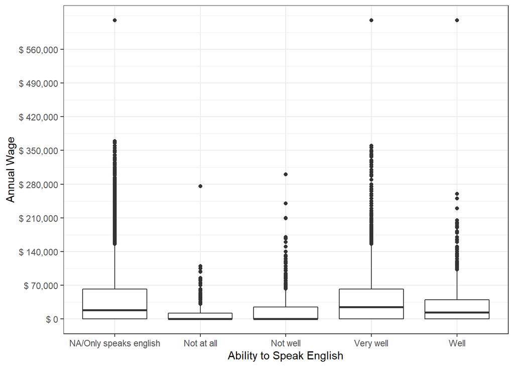

```r
ggplot(filtered_dataset, aes(x = ENG_label, y = WAGP)) +
  geom_boxplot() +
  theme_bw() +
  theme(axis.text.x = element_text(angle = 0)) +
  scale_x_discrete(name = "Ability to Speak English", labels=c("N/A (less than 5 years old/speaks only English)"="NA/Only speaks english")
                   ) +
  scale_y_continuous(name = "Annual Wage",
                     breaks = seq(0, 620000, by = 70000),
                     labels = paste("$",
                                    prettyNum(seq(0, 620000, by = 70000),
                                              big.mark = ",")))
```

This is not a very useful plot because it does not show the wage variation of most of the people.

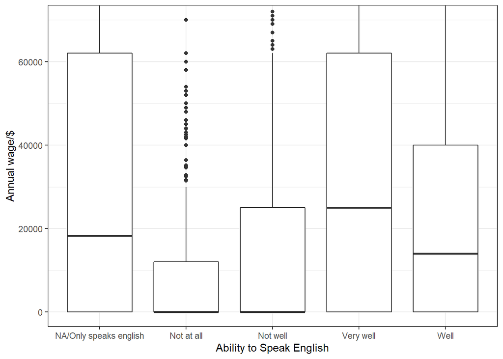

```r
ggplot(filtered_dataset, aes(x = ENG_label, y = WAGP)) +
  geom_boxplot() +
  theme_bw() +
  theme(axis.text.x = element_text(angle = 0)) +
  scale_x_discrete(name = "Ability to Speak English", labels=c("N/A (less than 5 years old/speaks only English)"="NA/Only speaks english")
                   ) +
  coord_cartesian(ylim=c(0,70000)) +
  ylab("Annual wage/$")
```

```r
# perform ANOVA test between age and ability to speak english.
anova_test = aov(AGEP ~ ENG_label,data=filtered_dataset)
summary(anova_test)
```

```
##                Df   Sum Sq Mean Sq F value Pr(>F)
## ENG_label       4   520152  130038   358.4 <2e-16 ***
## Residuals   57508 20865565     363
## ---
## Signif. codes:  0 '***' 0.001 '**' 0.01 '*' 0.05 '.' 0.1 ' ' 1
```

Since p-value<2.2e-16,there is sufficient evidence that there is a relationship between the 2 variables.

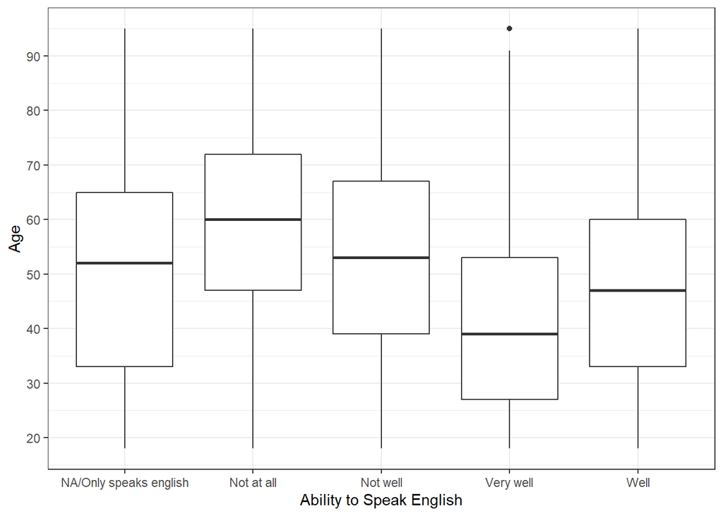

```r
ggplot(filtered_dataset, aes(x = ENG_label, y = AGEP)) +
  geom_boxplot() +
  theme_bw() +
  theme(axis.text.x = element_text(angle = 0)) +
  scale_x_discrete(name = "Ability to Speak English",labels=c("N/A (less than 5 years old/speaks only English)"="NA/Only speaks english")) +
  scale_y_continuous(name = "Age",
                     breaks = seq(0, 99, by = 10),
                     labels = paste(prettyNum(seq(0, 99, by = 10),
                                              big.mark = ",")))
```

Among the selected population group, the younger someone is, the more likely he or she will report a higher level of English proficiency.

```r
# perform ANOVA test between work hours and ability to speak English.
anova_test = aov(WKHP ~ ENG_label,data=filtered_dataset)
summary(anova_test)
```

```
##                Df   Sum Sq Mean Sq F value Pr(>F)
## ENG_label       4   229539   57385   135.8 <2e-16 ***
## Residuals   57508 24307845     423
## ---
## Signif. codes:  0 '***' 0.001 '**' 0.01 '*' 0.05 '.' 0.1 ' ' 1
```

Since p-value<2.2e-16,there is sufficient evidence that there is a relationship between the 2 variables.

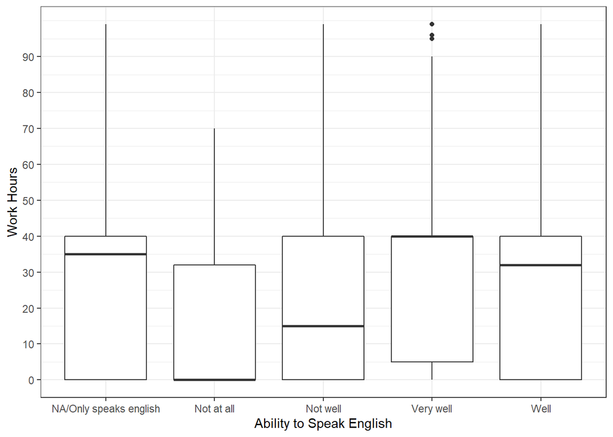

```r
ggplot(filtered_dataset, aes(x = ENG_label, y = WKHP)) +
  geom_boxplot() +
  theme_bw() +
  theme(axis.text.x = element_text(angle = 0)) +
  scale_x_discrete(name = "Ability to Speak English",labels=c("N/A (less than 5 years old/speaks only English)"="NA/Only speaks english")) +
  scale_y_continuous(name = "Work Hours",
                     breaks = seq(0, 99, by = 10),
                     labels = paste(prettyNum(seq(0, 99, by = 10),
                                              big.mark = ",")))
```

In the selected population group, the better someone’s English speaking skills are the longer hours he or she will work in a given week.

```r
# perform ANOVA test between annual wage and citizenship status.
anova_test = aov(WAGP ~ CIT_label,data=filtered_dataset)
summary(anova_test)
```

```
##                Df    Sum Sq   Mean Sq F value Pr(>F)
## CIT_label       4 6.020e+11 1.505e+11    29.7 <2e-16 ***
## Residuals   57508 2.914e+14 5.067e+09
## ---
## Signif. codes:  0 '***' 0.001 '**' 0.01 '*' 0.05 '.' 0.1 ' ' 1
```

Since p-value<2.2e-16,there is sufficient evidence that there is a relationship between the 2 variables.

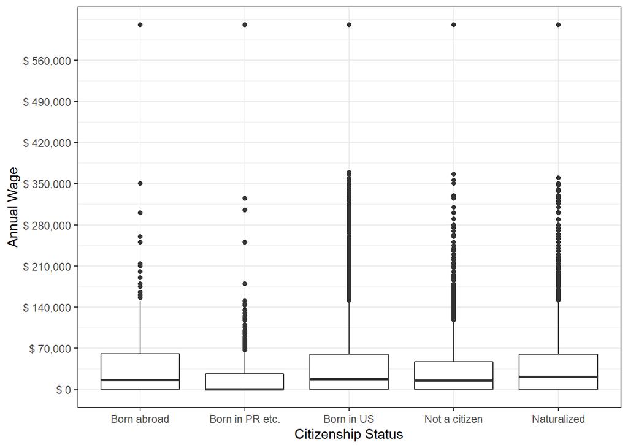

```r
ggplot(filtered_dataset, aes(x = CIT_label, y = WAGP)) +
  geom_boxplot() +
  theme_bw() +
  theme(axis.text.x = element_text(angle = 0)) +
  scale_x_discrete(name = "Citizenship Status",labels=c("Born abroad of American parent(s)" ="Born abroad",
                                                        "Born in Puerto Rico, Guam, the U.S. Virgin Islands, or the Northern Marianas" = "Born in PR etc.",
                                                        "Born in the U.S." = "Born in US",
                                                        "Not a citizen of the U.S." = "Not a citizen",
                                                        "U.S. citizen by naturalization" = "Naturalized")) +
  scale_y_continuous(name = "Annual Wage",
                     breaks = seq(0, 620000, by = 70000),
                     labels = paste("$",
                                    prettyNum(seq(0, 620000, by = 70000),
                                              big.mark = ",")))
```

This is not a very useful plot because it does not show the wage variation of most of the people.

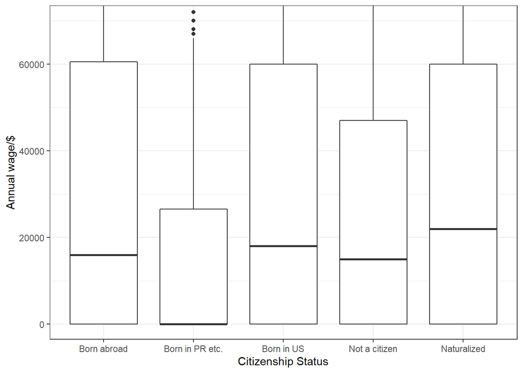

```r
ggplot(filtered_dataset, aes(x = CIT_label, y = WAGP)) +
  geom_boxplot() +
  theme_bw() +
  theme(axis.text.x = element_text(angle = 0)) +
  scale_x_discrete(name = "Citizenship Status",labels=c("Born abroad of American parent(s)" ="Born abroad",
                                                        "Born in Puerto Rico, Guam, the U.S. Virgin Islands, or the Northern Marianas" = "Born in PR etc.",
                                                        "Born in the U.S." = "Born in US",
                                                        "Not a citizen of the U.S." = "Not a citizen",
                                                        "U.S. citizen by naturalization" = "Naturalized")) +
  coord_cartesian(ylim = c(0,70000)) +
  ylab("Annual wage/$")
```

Citizenship status doesn’t seem to correlate to anuual wage unless someone is born in Puerto Rico, Guam, the U.S. Virgin Islands, or the Northern Marianas.

```r
# perform ANOVA test between age and citizenship status.
anova_test = aov(AGEP ~ CIT_label,data=filtered_dataset)
summary(anova_test)
```

```
##                Df   Sum Sq Mean Sq F value Pr(>F)
## CIT_label       4   401467  100367   275.1 <2e-16 ***
## Residuals   57508 20984250     365
## ---
## Signif. codes:  0 '***' 0.001 '**' 0.01 '*' 0.05 '.' 0.1 ' ' 1
```

Since p-value<2.2e-16,there is sufficient evidence that there is a relationship between the 2 variables.

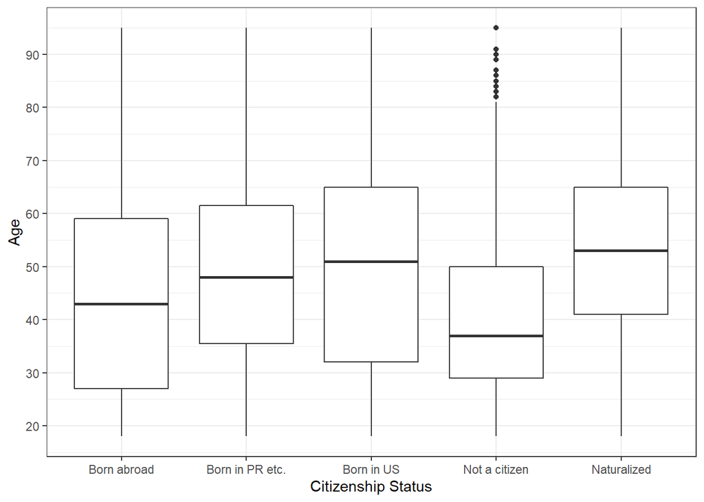

```r
ggplot(filtered_dataset, aes(x = CIT_label, y = AGEP)) +
  geom_boxplot() +
  theme_bw() +
  theme(axis.text.x = element_text(angle = 0)) +
  scale_x_discrete(name = "Citizenship Status",labels=c("Born abroad of American parent(s)" ="Born abroad",
                                                        "Born in Puerto Rico, Guam, the U.S. Virgin Islands, or the Northern Marianas" = "Born in PR etc.",
                                                        "Born in the U.S." = "Born in US",
                                                        "Not a citizen of the U.S." = "Not a citizen",
                                                        "U.S. citizen by naturalization" = "Naturalized")) +
  scale_y_continuous(name = "Age",
                     breaks = seq(0, 99, by = 10),
                     labels = paste(prettyNum(seq(0, 99, by = 10),
                                              big.mark = ",")))
```

In the selected population, people who are not citizens seem to be substantially younger than the rest of the population.

```r
# perform ANOVA test between work hours and citizenship status.
anova_test = aov(WKHP ~ CIT_label,data=filtered_dataset)
summary(anova_test)
```

```
##                Df   Sum Sq Mean Sq F value Pr(>F)
## CIT_label       4    54433   13608   31.96 <2e-16 ***
## Residuals   57508 24482951     426
## ---
## Signif. codes:  0 '***' 0.001 '**' 0.01 '*' 0.05 '.' 0.1 ' ' 1
```

Since p-value<2.2e-16,there is sufficient evidence that there is a relationship between the 2 variables.

[figure not shown]

```r
ggplot(filtered_dataset, aes(x = CIT_label, y = AGEP)) +
  geom_boxplot() +
  theme_bw() +
  theme(axis.text.x = element_text(angle = 0)) +
  scale_x_discrete(name = "Citizenship Status",labels=c("Born abroad of American parent(s)" ="Born abroad",
                                                        "Born in Puerto Rico, Guam, the U.S. Virgin Islands, or the Northern Marianas" = "Born in PR etc.",
                                                        "Born in the U.S." = "Born in US",
                                                        "Not a citizen of the U.S." = "Not a citizen",
                                                        "U.S. citizen by naturalization" = "Naturalized")) +
  scale_y_continuous(name = "Work Hours",
                     breaks = seq(0, 99, by = 10),
                     labels = paste(prettyNum(seq(0, 99, by = 10),
                                              big.mark = ",")))
```